# Final Project Part 2: Data Analysis

Jailene Gonzalez

2022-12-07

# Data Exploration

## Numerical Exploration

Create a code chunk that includes the following:

- Use `summary()` on the body mass and body length data columns in the Delomys data set to display summary statistics.
- Perform a test of normality on the body mass and length columns. You can use `shapiro.test()`

```
##    Min. 1st Qu.  Median    Mean 3rd Qu.    Max.
##    5.00   35.00   43.00   44.06   54.00  105.00
```

```
##    Min. 1st Qu.  Median    Mean 3rd Qu.    Max.
##    49.0   106.0   116.0   114.7   124.0   265.0
```

```
##
##  Shapiro-Wilk normality test
##
## data:  delomys$body_mass
## W = 0.99506, p-value = 4.33e-05
```

```
##
##  Shapiro-Wilk normality test
##
## data:  delomys$body_length
## W = 0.87609, p-value < 2.2e-16
```

## Graphical Exploration

#### 1. A scatterplot of body mass and body length.

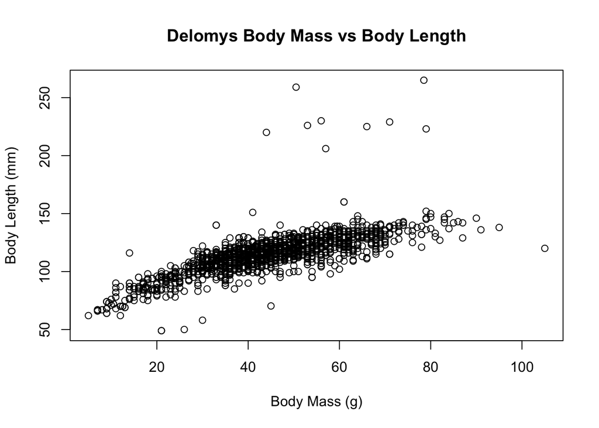

#### 2. A histogram of body mass

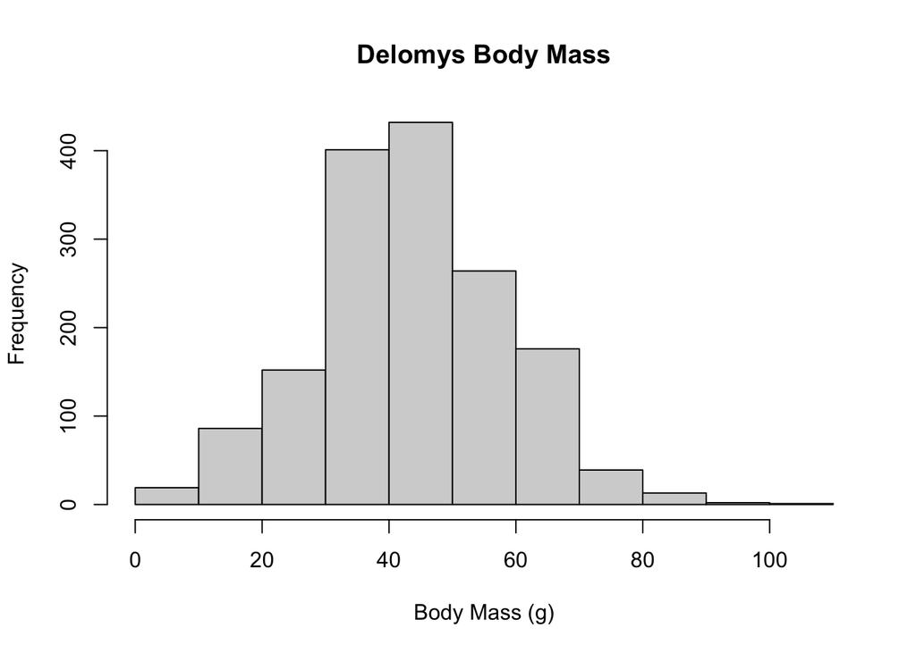

#### 3. A histogram of body length

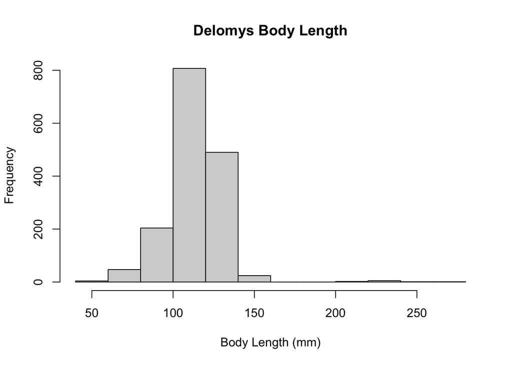

#### 4. A conditional boxplot of body mass, conditioned on species (column `binomial`)

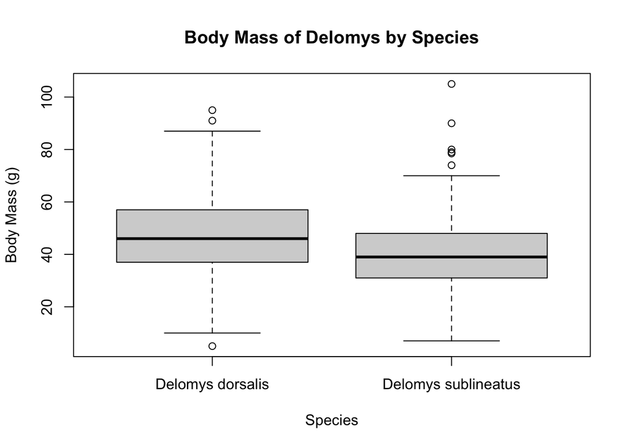

#### 5. A conditional boxplot of body mass, conditioned on sex (column `sex`)

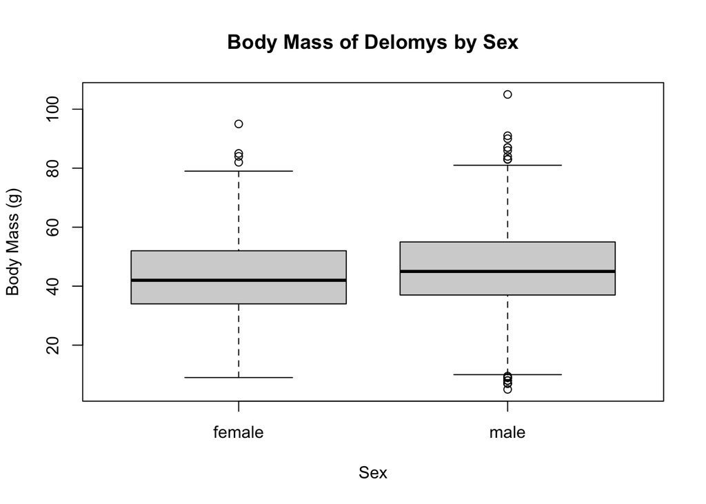

#### 6. A conditional boxplot of body mass, conditioned on both species and sex

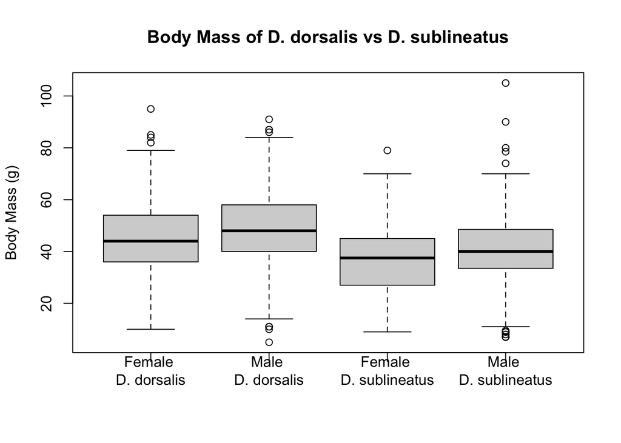

### Q1-4: Data Exploration

Answer the following in your report:

**Q1 (2 pts.): Qualitatively describe the relationship between body mass and length. Does the relationship seem linear, curved, nonexistent?**

**Q2 (2 pts.): Qualitatively describe the shapes of the histograms.** Do the data appear normally-distributed? Explain why or why not. Explain why we care (or not) whether the data are normally distributed.

- The shape of the histogram showing delomys body mass appears to be more normally distributed than body length. Delomys body length appears to not be normally distributed because it seems to be slightly skewed. On another note: we care about data being normally distributed because it allows us to use an approach/model that replicates the natural world through the use of continuous data.

**Q3 (2 pts.): Using both the histograms and normality tests, do you think the (unconditioned) body masses and body length are normally-distributed? Make sure you contrast your visual assessment of normality to the results of the numerical normality tests.**

- Initially, when we looked at the histograms for body mass and body length I thought that the only one that appeared to be normally distributed was the histogram for body mass. However, after conducting normality tests (shapiro tests) for the delomy’s body masses and body lengths, they both were not normally distributed. They are both not normally distributed because their shapiro test results showed that they had a p-value less than 0.05.

**Q4 (2 pts.): Examine the three conditional boxplots. Describe any graphical evidence you see for body mass differences based on species and/or sex.**

- When I looked at the conditional boxplot of body mass, conditioned on species (column binomial), it seems that D. dorsalis has a higher median value than D. sublineatus. Then, when I made a conditional boxplot of body mass that was conditioned on sex, it showed that male delomys had a slightly higher median value than female delomys. Lastly, I made another conditional boxplot of body mass, conditioned on both species and sex and we can see that the male counterpart of both species had a higher mean value than their female counterparts.

## Model Building

#### Model 1: simple linear regression `body_length ~ body_mass`

```
##
## Call:
## lm(formula = body_length ~ body_mass, data = delomys)
##
## Residuals:
##     Min      1Q  Median      3Q     Max
## -48.888  -5.398   0.104   4.859 138.663
##
## Coefficients:
##             Estimate Std. Error t value Pr(>|t|)
## (Intercept) 76.12466    0.91581   83.12   <2e-16 ***
## body_mass    0.87550    0.01969   44.46   <2e-16 ***
## ---
## Signif. codes:  0 '***' 0.001 '**' 0.01 '*' 0.05 '.' 0.1 ' ' 1
##
## Residual standard error: 11.67 on 1583 degrees of freedom
## Multiple R-squared:  0.5553, Adjusted R-squared:  0.5551
## F-statistic:  1977 on 1 and 1583 DF,  p-value: < 2.2e-16
```

#### Model 2: 1-way ANOVA `body_mass ~ sex`

```
## Analysis of Variance Table
##
## Response: body_mass
##             Df Sum Sq Mean Sq F value    Pr(>F)
## sex          1   3062 3061.68  13.943 0.0001951 ***
## Residuals 1578 346507  219.59
## ---
## Signif. codes:  0 '***' 0.001 '**' 0.01 '*' 0.05 '.' 0.1 ' ' 1
```

#### Model 3: 1-way ANOVA `body_mass ~ binomial`

```
## Analysis of Variance Table
##
## Response: body_mass
##             Df Sum Sq Mean Sq F value    Pr(>F)
## binomial     1  21290 21289.7  102.08 < 2.2e-16 ***
## Residuals 1583 330164   208.6
## ---
## Signif. codes:  0 '***' 0.001 '**' 0.01 '*' 0.05 '.' 0.1 ' ' 1
```

#### Model 4: 2-way additive ANOVA `body_mass ~ sex + binomial`

```
## Analysis of Variance Table
##
## Response: body_mass
##             Df Sum Sq Mean Sq F value    Pr(>F)
## sex          1   3062  3061.7  14.958 0.0001144 ***
## binomial     1  23727 23727.1 115.923 < 2.2e-16 ***
## Residuals 1577 322780   204.7
## ---
## Signif. codes:  0 '***' 0.001 '**' 0.01 '*' 0.05 '.' 0.1 ' ' 1
```

#### Model 5: 2-way factorial ANOVA `body_mass ~ sex * binomial`

```
## Analysis of Variance Table
##
## Response: body_mass
##                Df Sum Sq Mean Sq  F value    Pr(>F)
## sex             1   3062  3061.7  14.9489  0.000115 ***
## binomial        1  23727 23727.1 115.8500 < 2.2e-16 ***
## sex:binomial    1      1     0.8   0.0039  0.950442
## Residuals    1576 322779   204.8
## ---
## Signif. codes:  0 '***' 0.001 '**' 0.01 '*' 0.05 '.' 0.1 ' ' 1
```

## Model Diagnostic

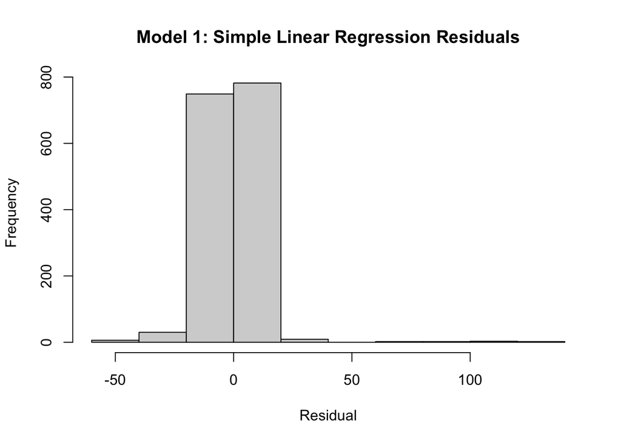

```
##
##  Shapiro-Wilk normality test
##
## data:  fit_1_res
## W = 0.73462, p-value < 2.2e-16
```

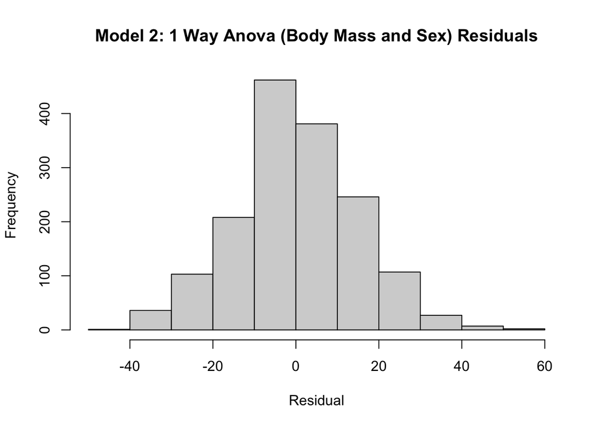

```
##
##  Shapiro-Wilk normality test
##
## data:  fit_2_res
## W = 0.99563, p-value = 0.0001541
```

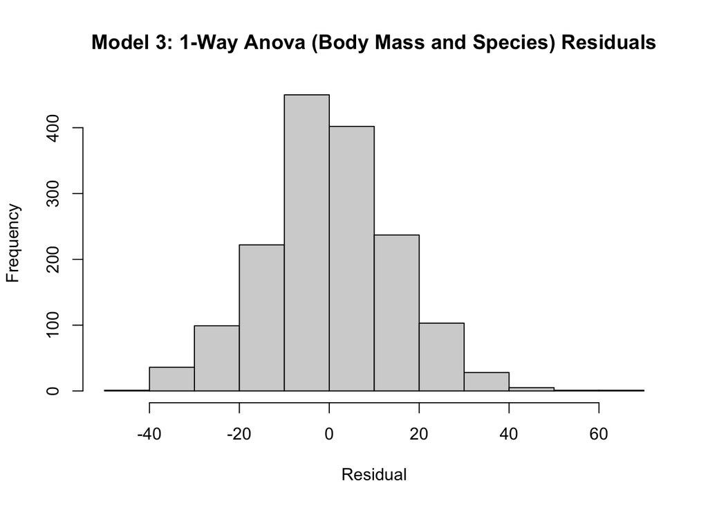

```
##
##  Shapiro-Wilk normality test
##
## data:  fit_3_res
## W = 0.99535, p-value = 8.103e-05
```

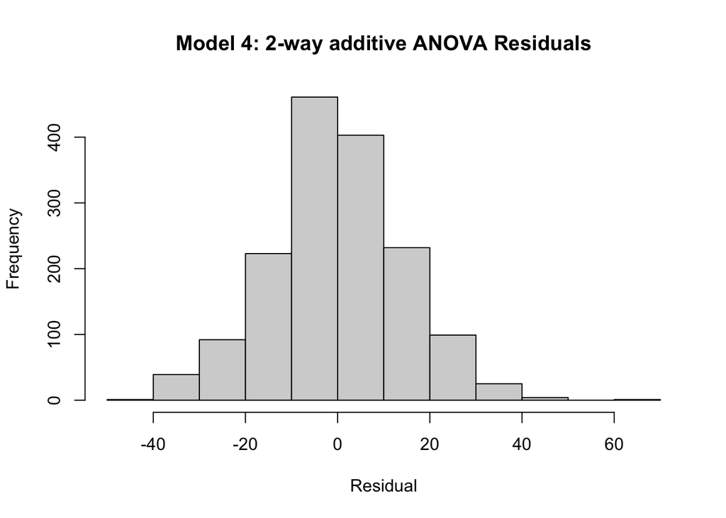

```
##
##  Shapiro-Wilk normality test
##
## data:  fit_4_res
## W = 0.99525, p-value = 6.805e-05
```

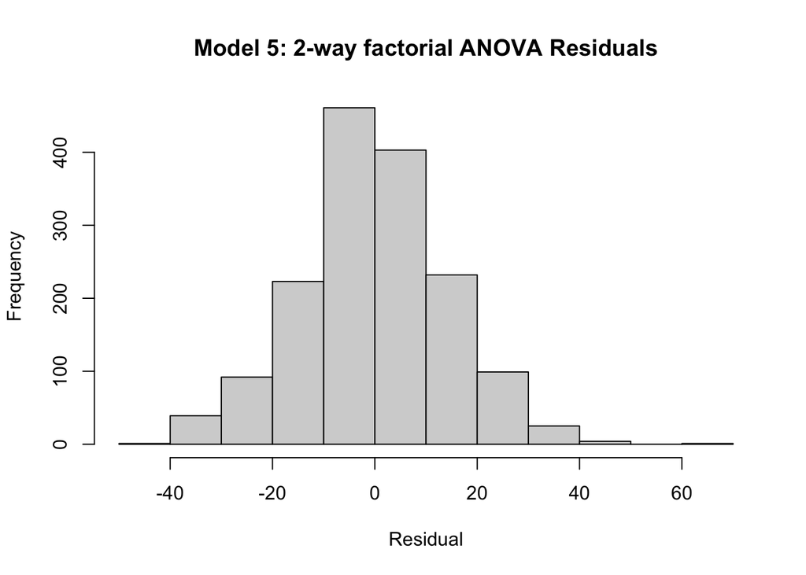

```
##
##  Shapiro-Wilk normality test
##
## data:  fit_5_res
## W = 0.99526, p-value = 6.816e-05
```

### Q5-6: Model Assumptions

Answer the following in your report:

**Q5 (2 pts.): What do you conclude about residual normality based on the numerical and graphical diagnostics?**

- Based on the numerical and graphical diagnostics for the residuals in our models, we can conclude that none of them exhibited normality. They were not normally distributed because they all had a p-value that was less than 0.05 when we conducted a shapiro test.

**Q6 (1 pt.): Are violations of the normality assumption equally severe for all the models?**

- No they are not equally severe for all the models.

## Model Interpretation

### Q 7-9: Simple Linear Regression

Print the model coefficient table.

#### **Model 1: Simple Linear Regression**

|  | Estimate | Std. Error | t value | Pr(>\|t\|) |
| --- | --- | --- | --- | --- |
| (Intercept) | 76.12 | 0.92 | 83.12 | 0 |
| body_mass | 0.88 | 0.02 | 44.46 | 0 |

**Q7 (2 pts.): What is the magnitude of the mass/length relationship?**

**Q8 (2 pts.): What is the expected body length of an animal that weighs 100g?**

- The expected body length of an animal that weighs 100g is 164.12.

**Q9 (2 pts.): What is the expected body length of an animal that weighs 0g?**

- The expected body length of an animal that weighs 0g is 76.12.

### Q 10-13: Body Mass: Coefficient Tables

Print the model coefficient tables for each of the body mass model fits.

#### **Model 2: 1-way ANOVA `body_mass ~ sex`**

|  | Estimate | Std. Error | t value | Pr(>\|t\|) |
| --- | --- | --- | --- | --- |
| (Intercept) | 42.71 | 0.53 | 80.76 | 0 |
| sexmale | 2.78 | 0.75 | 3.73 | 0 |

#### **Model 3: 1-way ANOVA `body_mass ~ binomial`**

|  | Estimate | Std. Error | t value | Pr(>\|t\|) |
| --- | --- | --- | --- | --- |
| (Intercept) | 46.75 | 0.45 | 103.9 | 0 |
| binomialDelomys sublineatus | -7.68 | 0.76 | -10.1 | 0 |

#### **Model 4: 2-way additive ANOVA**

|  | Estimate | Std. Error | t value | Pr(>\|t\|) |
| --- | --- | --- | --- | --- |
| (Intercept) | 45.07 | 0.56 | 81.11 | 0 |
| sexmale | 3.80 | 0.73 | 5.23 | 0 |
| binomialDelomys sublineatus | -8.19 | 0.76 | -10.77 | 0 |

#### **Model 5: 2- way factorial ANOVA**

|  | Estimate | Std. Error | t value | Pr(>\|t\|) |
| --- | --- | --- | --- | --- |
| (Intercept) | 45.06 | 0.61 | 74.44 | 0.00 |
| sexmale | 3.83 | 0.90 | 4.27 | 0.00 |
| binomialDelomys sublineatus | -8.14 | 1.13 | -7.22 | 0.00 |
| sexmale:binomialDelomys sublineatus | -0.10 | 1.53 | -0.06 | 0.95 |

**Q10 (1 pt.): What is the base level for sex?**

- The base level for sex is sexfemale.

**Q11 (1 pt.): What is the base level for binomial?**

- The base level for binomial is binomialDemolysdorsalis.

**Q12 (1 pt.): Which sex is heavier? How do you know?**

- The heavier sex is male because the estimate for sexmale is a positive number (indicating that it is larger than the base level sex, sexfemale).

**Q13 (1 pt.): Which species is heavier? How do you know?**

- The heavier species is Demolys dorsalis because the estimate value for binomialDemolyssublineatus is negative (indicating that it is smaller than the base level binomial).

### Q 14-16: ANOVA Tables

Print the ANOVA tables for each of the body mass models.

#### **Model 2: 1-way ANOVA `body_mass ~ sex`**

|  | Df | Sum Sq | Mean Sq | F value | Pr(>F) |
| --- | --- | --- | --- | --- | --- |
| sex | 1 | 3061.68 | 3061.68 | 13.94 | 0 |
| Residuals | 1578 | 346507.13 | 219.59 | NA | NA |

#### **Model 3: 1-way ANOVA `body_mass ~ binomial`**

|  | Df | Sum Sq | Mean Sq | F value | Pr(>F) |
| --- | --- | --- | --- | --- | --- |
| binomial | 1 | 21289.68 | 21289.68 | 102.08 | 0 |
| Residuals | 1583 | 330164.45 | 208.57 | NA | NA |

#### **Model 4: 2-way additive ANOVA**

|  | Df | Sum Sq | Mean Sq | F value | Pr(>F) |
| --- | --- | --- | --- | --- | --- |
| sex | 1 | 3061.68 | 3061.68 | 14.96 | 0 |
| binomial | 1 | 23727.13 | 23727.13 | 115.92 | 0 |
| Residuals | 1577 | 322780.00 | 204.68 | NA | NA |

#### **Model 5: 2- way factorial ANOVA**

|  | Df | Sum Sq | Mean Sq | F value | Pr(>F) |
| --- | --- | --- | --- | --- | --- |
| sex | 1 | 3061.68 | 3061.68 | 14.95 | 0.00 |
| binomial | 1 | 23727.13 | 23727.13 | 115.85 | 0.00 |
| sex:binomial | 1 | 0.79 | 0.79 | 0.00 | 0.95 |
| Residuals | 1576 | 322779.21 | 204.81 | NA | NA |

Answer the following in your report:

**Q14 (1 pt.): Are sex and species significant predictors for body mass?**

**Q15 (1 pt.): Is there a significant interaction?**

**Q16 (2 pts.): Examine the p-values for the main effects (sex and species) in all four of the ANOVA tables. Does the significance level of either main effect change very much among the different models?**

- The significance level among the different models does not change very much since their p-value were so small and less than 0.05.

## Model Comparison: Body Mass

You built four different models of body mass. How do you choose the best one?

One option is to choose the model with the lowest AIC. You can calculate AIC using the appropriately named `AIC()` function.

Create a code chunk that calculates the AIC values for each of the body mass models.

##### AIC for Model 2

```
## [1] 13006.8
```

##### AIC for Model 3

```
## [1] 12966.36
```

##### AIC for Model 4

```
## [1] 12896.73
```

##### AIC for Model 5

```
## [1] 12898.72
```

### Q17-18: Model Comparison

**Q17 (1 pt.): Which two models have the lowest AIC?**

- The two models that had the lowest AIC values are Model 4: 2-way additive ANOVA (fit4) and Model 5: 2-way factorial ANOVA (fit5).

**Q18 (4 pts.): Which of the two models with lowest AIC scores would you select? Explain your decision based on model fit and the complexity/understanding tradeoff.**

- From the two models with the lowest AIC scores, I would select Model 4: 2-way additive ANOVA because it had the lowest AIC score. I went with this choice because AIC (Akaike information criterion) helps you select the best fit model using a mathematical approach in order to find the model that explains the most variation by using the least amount of parameters. I decided to opt away from using Model 5, the interactive model, because it was more complex than the additive model. The interactive model takes into account the interaction between both independent variables.